# Case study - Exploratory data analysis

Douglas Silva Alves

2024-06-18

# About this document

Welcome! This document represents one of my projects as a beginner data scientist. In this project, I take on the role of a junior data analyst tasked with a project for a fictitious company.

# Project Overview

**Business task:** Analyzing data from a company to identify distribution differences in socioeconomic variables, as well as whether the workers’ salaries are influenced by these variables.

## Key Questions:

The key questions will be highlighted throughout the document.

# Data for this project

The data for this project is not publicly available.

# Loading packages

First, let’s load the packages we will need for the data analysis.

```python
import pandas as pd
import matplotlib.pyplot as plt
from scipy.stats import f_oneway
from scipy.stats import chi2_contingency
from scipy.stats import ttest_1samp
from statsmodels.stats.anova import AnovaRM
```

# Loading dataset

```python
dados = pd.read_spss('dados_lista1.sav')
```

## Let’s have a look in our data

```python
dados.head()
```

```
##    estado_c grau_de  n_mero_d  sal_rio  ...    origem sal_rio1  sal_rio2  Zn_mero_d
## 0  Solteiro  1 Grau       0.0     4.00  ...  Interior     4.56      6.86  -0.732915
## 1  Solteiro  2 Grau       0.0     5.73  ...     Outro     6.26      7.44  -0.732915
## 2  Solteiro  1 Grau       0.0     6.26  ...     Outro     6.66      8.12  -0.732915
## 3  Solteiro  1 Grau       0.0     6.86  ...  Interior     7.39      6.66  -0.732915
## 4  Solteiro  1 Grau       0.0     7.39  ...   Capital     9.35      6.86  -0.732915
##
## [5 rows x 9 columns]
```

We have a database with 36 workers in a company. Let’s conduct an exploratory analysis based on pre-established questions.

## Question 1 - Plot frequency tables for data relating to level of education, marital status and region of origin

For this, let’s use the ‘crosstab’ method from pandas

```python
frequency_table = pd.crosstab(dados['grau_de'], 'count')
```

Let’s compute a variable to see the relative proportions

```python
frequency_table['percentage'] = frequency_table/len(dados)
```

To improve the interpretation, let’s multiply the relative proportion by 100

```python
frequency_table['percentage'] = frequency_table['percentage']*100
```

Let’s have a look at our frequency table

```python
frequency_table
```

```
## col_0     count  percentage
## grau_de
## 1 Grau       12   33.333333
## 2 Grau       18   50.000000
## Superior      6   16.666667
```

We can see that the greater proportion of individuals from this company have a second degree qualification.

Now, let’s do the same for the other categorical variables

```python
frequency_marital = pd.crosstab(dados['estado_c'], 'count')

frequency_marital['percentage'] = frequency_marital/len(dados)*100

frequency_marital
```

```
## col_0     count  percentage
## estado_c
## Casado       20   55.555556
## Solteiro     16   44.444444
```

```python
frequency_origin_region = pd.crosstab(dados['origem'], 'count')

frequency_origin_region['percentage'] = frequency_origin_region/len(dados)*100

frequency_origin_region
```

```
## col_0     count  percentage
## origem
## Capital      11   30.555556
## Interior     12   33.333333
## Outro        13   36.111111
```

## Question 2 - Graph the above tables

Let’s do it using subplots.

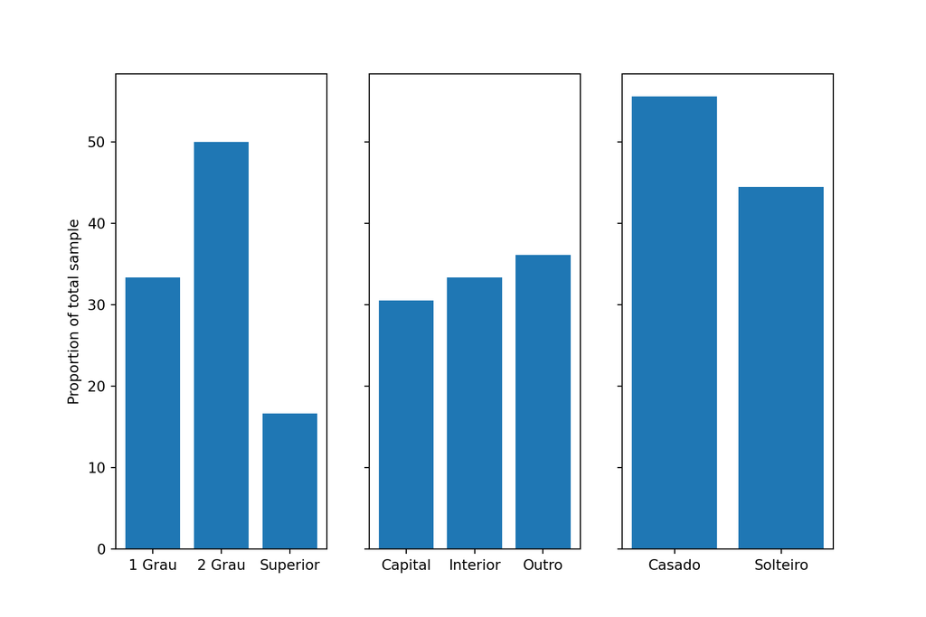

```python
fig, (ax1, ax2, ax3) = plt.subplots(1, 3, figsize=(9, 6), sharey=True)
ax1.bar(frequency_table.index, frequency_table['percentage'])
ax1.set_ylabel('Proportion of total sample')
ax2.bar(frequency_origin_region.index, frequency_origin_region['percentage'])
ax3.bar(frequency_marital.index, frequency_marital['percentage'])
plt.show()
```

## Question 3 - Compare, statistically (α=5%), whether there are differences in the distribution of the number of children and the average age depending on the regions of origin of the workers

First, as a prerequisite for using tests based on the arithmetic mean (such as ANOVA or t-test), let’s examine the distribution of our dependent variables (age and number of children) using histograms.

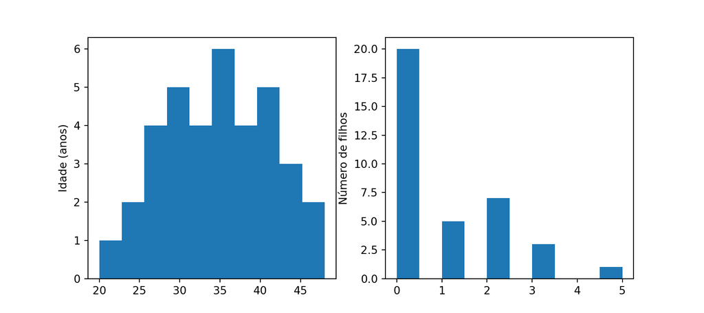

```python
fig, (ax1, ax2) = plt.subplots(1, 2, figsize=(9, 4))
ax1.hist(dados['idade'])
ax1.set_ylabel('Idade (anos)')
ax2.hist(dados['n_mero_d'])
ax2.set_ylabel('Número de filhos')
plt.show()
```

```python
anova_age = f_oneway(dados['idade'][dados['origem'] == 'Interior'],
                     dados['idade'][dados['origem'] == 'Capital'],
                     dados['idade'][dados['origem'] == 'Outro'])

anova_childs = f_oneway(dados['n_mero_d'][dados['origem'] == 'Interior'],
                     dados['n_mero_d'][dados['origem'] == 'Capital'],
                     dados['n_mero_d'][dados['origem'] == 'Outro'])

anova_age
```

```
## F_onewayResult(statistic=0.46364349092176166, pvalue=0.6330227578121678)
```

```python
anova_childs
```

```
## F_onewayResult(statistic=0.5761668190480387, pvalue=0.5676016691322265)
```

For both tests it was not possible to see any effect of origin!

## Question 4 - Calculate the average salary and average age of single and married people

```python
age_marital = dados.groupby('estado_c')['idade'].describe()
salary_marital = dados.groupby('estado_c')['sal_rio1'].describe()

age_marital
```

```
##           count    mean       std   min    25%   50%    75%   max
## estado_c
## Casado     20.0  35.150  5.896252  26.0  30.75  34.5  39.25  48.0
## Solteiro   16.0  33.875  7.804913  20.0  26.75  35.5  40.25  46.0
```

```python
salary_marital
```

```
##           count      mean       std   min   25%    50%      75%   max
## estado_c
## Casado     20.0   9.48250  5.089095  2.50  5.61  8.315  11.6925  19.4
## Solteiro   16.0  10.74125  4.981918  4.56  6.81  9.800  13.2700  23.3
```

## Question 5 - Check the association between marital status and level of education. Is it possible to say that there is a significant association between marital status and level of education (α=5%)?

To test this association, let’s use a chi-square test.

First, let’s calculate the contingency table

```python
contingency_marital_edu = pd.crosstab(dados['estado_c'], dados['grau_de'])
```

Now let’s to apply the test to our contingency table

```python
chi2, p_value, _, _ = chi2_contingency(contingency_marital_edu)
```

Let’s see the contingency table

```python
contingency_marital_edu
```

```
## grau_de   1 Grau  2 Grau  Superior
## estado_c
## Casado         5      12         3
## Solteiro       7       6         3
```

Let’s see the p value of our chi-square test

```python
p_value
```

```
## 0.3843314298815499
```

Based on the p-value we can see that there is not a relationship between marital status and level of education.

## Question 6 - According to IBGE data, the average age of the population of SP is 31 years old. Does the sample presented have a significant difference in mean age in relation to the population mean estimate?

To answer this question, let’s use a one-sample t test

```python
age_one_sample_t_test = ttest_1samp(dados['idade'], 31)
age_one_sample_t_test
```

```
## TtestResult(statistic=3.191131495300529, pvalue=0.0029888762085627553, df=35)
```

By means of a one-sample t-test, it is possible to see a significant difference (p = 0.003) between the age of our sample and the population mean, with a mean difference of 3.58 years.